# Benchmarking and Profiling

19 Sep 2016

## Benchmarking density estimation

```r
source("kernDens.R")
```

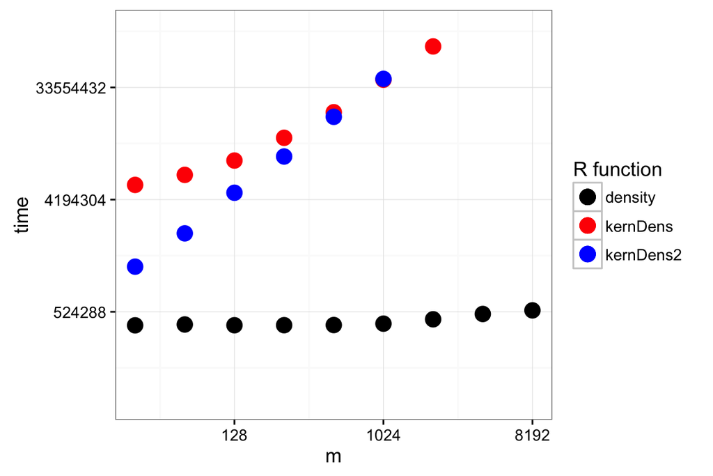

Source R code

## Function profiling

The code profiler in the utils package samples at regular intervals the call stack when code is executed. It gives information about the execution time spent "within" each function.

```r
x <- rnorm(2^15)
profFile <- "prof.Rprof"
Rprof(profFile)
tmp <- kernDens(x, 0.2)
Rprof(NULL)
```

```r
summaryRprof("prof.Rprof")
```

## Function profiling

```
## $by.self
##         self.time self.pct total.time total.pct
## "dnorm"      1.00    87.72       1.14    100.00
## "-"          0.14    12.28       0.14     12.28
##
## $by.total
##            total.time total.pct self.time self.pct
## "dnorm"          1.14    100.00      1.00    87.72
## "kern"           1.14    100.00      0.00     0.00
## "kernDens"       1.14    100.00      0.00     0.00
## "mean"           1.14    100.00      0.00     0.00
## "-"              0.14     12.28      0.14    12.28
##
## $sample.interval
## [1] 0.02
##
## $sampling.time
## [1] 1.14
```

## Recall the code of `kernDens`

```r
kernDens
```

```
## function (x, h, n = 512, kern = function(x, h) dnorm(x, sd = h))
## {
##     rg <- range(x)
##     xx <- seq(rg[1] - 3 * h, rg[2] + 3 * h, length.out = n)
##     y <- numeric(n)
##     for (i in seq_along(xx)) y[i] <- mean(kern(xx[i] - x, h))
##     list(x = xx, y = y, h = h)
## }
```

## Line profiling

The `profvis` package can summarize profiling information by line in the source code. The following code will open a profiling display when evaluated in RStudio.

```r
library("profvis")
profvis(kernDens(x, 0.2))
```

The result is an interactive HTML page, which can be saved and viewed in a browser.

In this case the line profiler is not very informative.

## Line profiling

The one-liner in the loop did too many things.

```r
profvis(kernDens2(x, 0.2))
```

The result of profiling the code for this function call is more informative.

## Practical work on Assignment 1 and 2

## Conclusions from profiling

A trick to reduce the \(nN\) kernel evaluations to a smaller number is *binning*.

(In the slides, \(n\) denotes the number of evaluation points for the estimate and \(N\) the length of the data vector.)

If \(N < n\) binning may not be beneficial.

## Binning

```r
kernDens3
```

```
## function (x, h, n = 512)
## {
##     kern = function(x, h) dnorm(x, sd = h)
##     if (missing(h))
##         h <- 1.06 * length(x)^(-0.2) * sd(x)
##     rg <- range(x) + c(-3 * h, 3 * h)
##     xx <- seq(rg[1], rg[2], length.out = n)
##     weights <- kernbin(x, rg[1], rg[2], n)
##     kerneval <- kern(xx - xx[1], h)
##     kerndif <- tmp[toeplitz(1:n)]
##     y <- colSums(weights * kerndif)
##     list(x = xx, y = y, h = h)
## }
```

## Binning

The `kernDens3` function uses bins around the grid points, where the density is evaluated, and counts the number of data points in each bin via the call to `kernbin`.

The `kernbin` function is a simple loop in R along the data vector.

You should note how arithmetic is used to determine which grid point is closest to a data point. This is much faster than a search along the grid points, and can be used when the grid points are equidistant.

## Binning

```r
kernbin
```

```
## function (x, lo, hi, n)
## {
##     w <- numeric(n)
##     delta <- (hi - lo)/(n - 1)
##     for (i in seq_along(x)) {
##         ii <- floor((x[i] - lo)/delta + 0.5) + 1
##         w[ii] <- w[ii] + 1
##     }
##     w/sum(w)
## }
```

## Benchmarking

```r
x <- rnorm(2^13)
tmp <- microbenchmark(
  kernDens3(x[1:32], 0.2),
  kernDens3(x[1:64], 0.2),
  kernDens3(x[1:128], 0.2),
  kernDens3(x[1:264], 0.2),
  kernDens3(x[1:512], 0.2),
  kernDens3(x[1:1024], 0.2),
  kernDens3(x[1:2048], 0.2),
  kernDens3(x[1:4096], 0.2),
  kernDens3(x, 0.2)
  )
m <- 2^(5:13)
resKern3 <- cbind(m, aggregate(time ~ expr, tmp, median))
```

The computations become faster for long sequences when binning is used.

## Benchmarking comparison

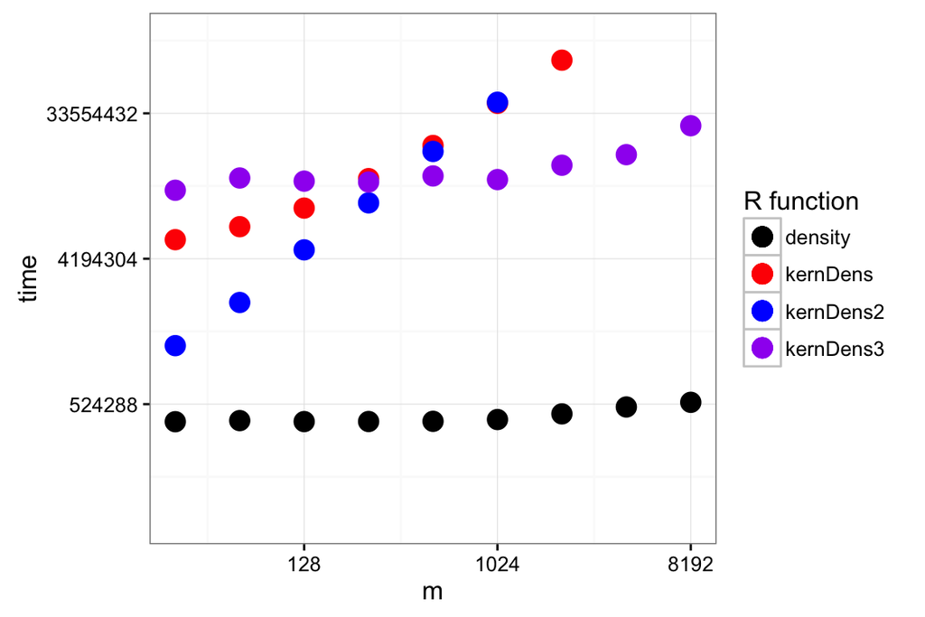

```r
p + geom_point(data = resKern3, size = 4, aes(color = "kern3"))
```

## Testing

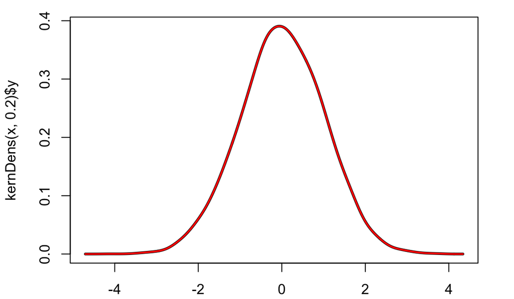

```r
plot(kernDens(x, 0.2), type = "l", lwd = 3)
lines(kernDens3(x, 0.2), col = "red", lwd = 2)
```

## Testing

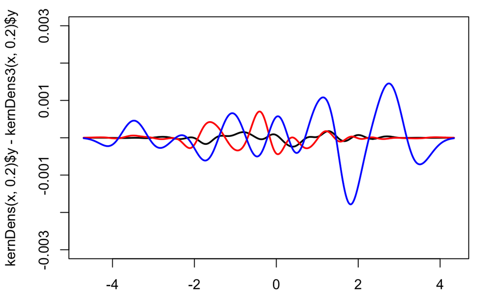

The absolute errors due to binning are small but increasing with decreasing length of data sequence. Length 8192 is black, length 1024 is red and length 128 is blue.

## Line profiling

The `kernDens3` function is so much faster for long sequences that to get good profiling results we use a 32 times longer data sequence.

```r
x <- rnorm(2^20)
profvis(kernDens3(x, 0.2))
```

The result shows that now the largest fraction of time is spent in the binning algorithm.